# Descriptive Statistics

## **Calculating Compound Return**

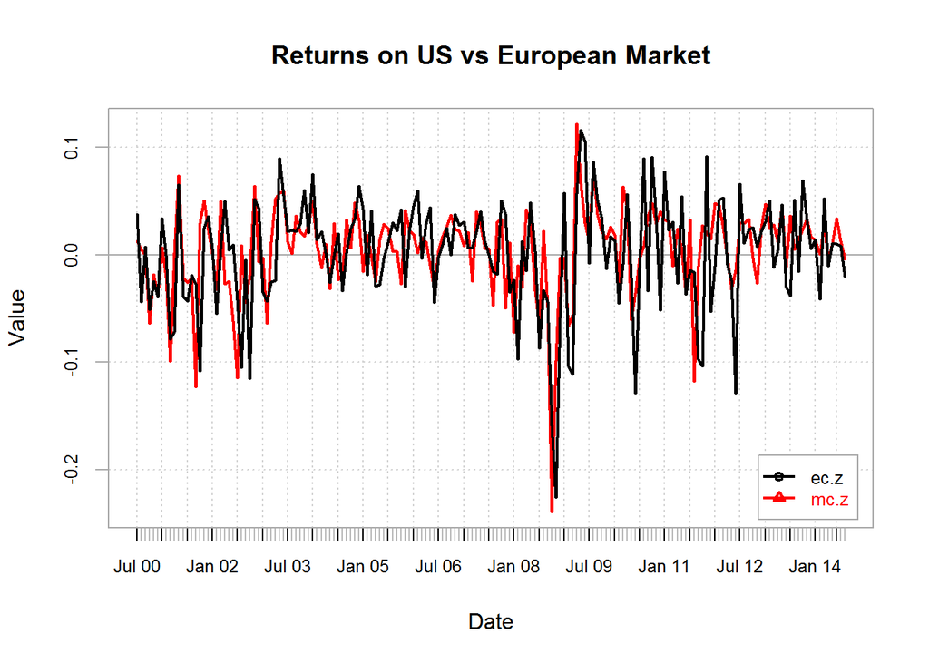

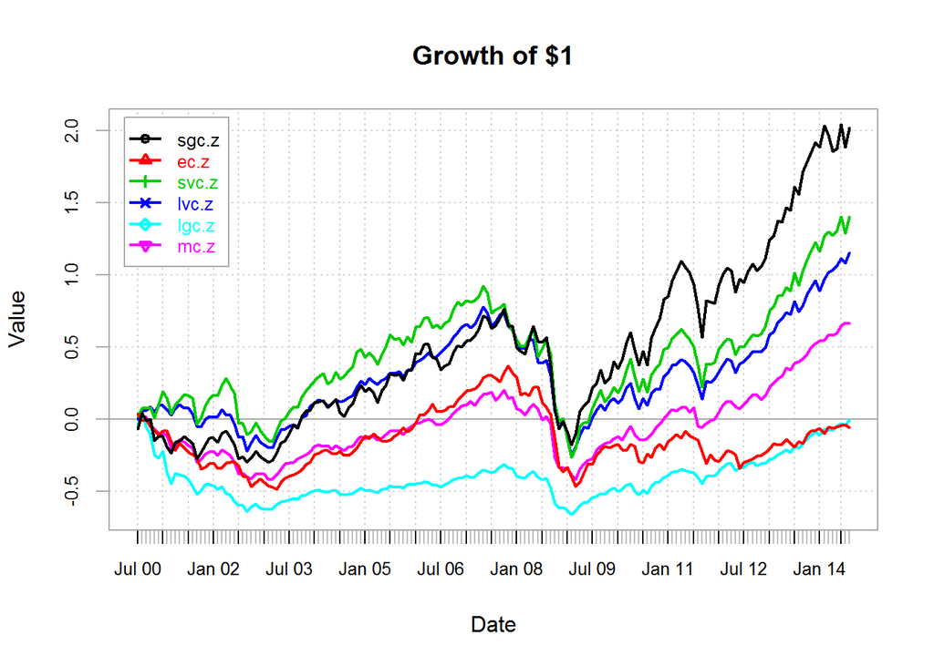

## **Examining the Frequency Distribution**

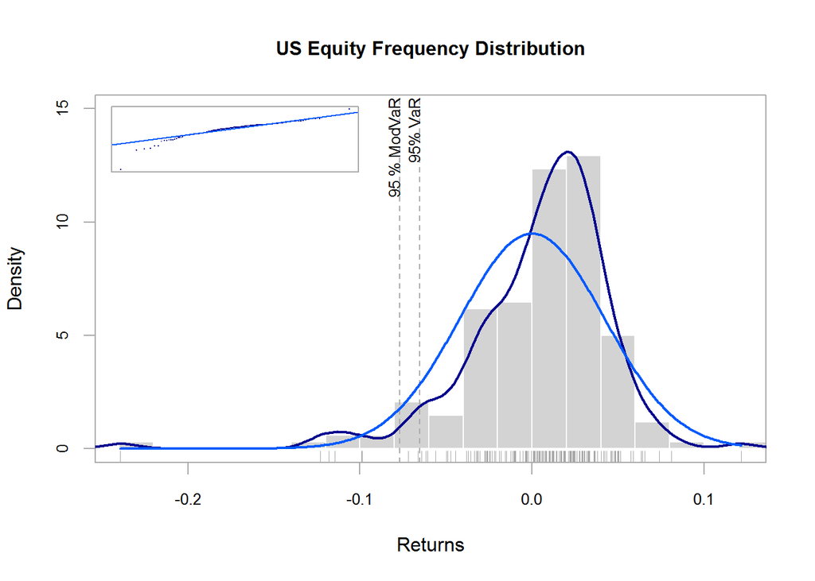

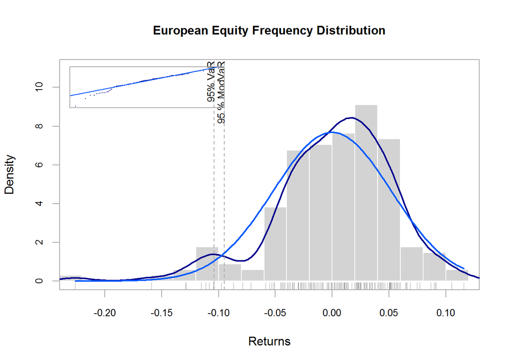

### **Charting Asset Classes with same Histogram Breaks to Facilitate Comparison**

```
## [1] "histogram"
```

```
## [1] "breaks"   "counts"   "density"  "mids"     "xname"    "equidist"
```

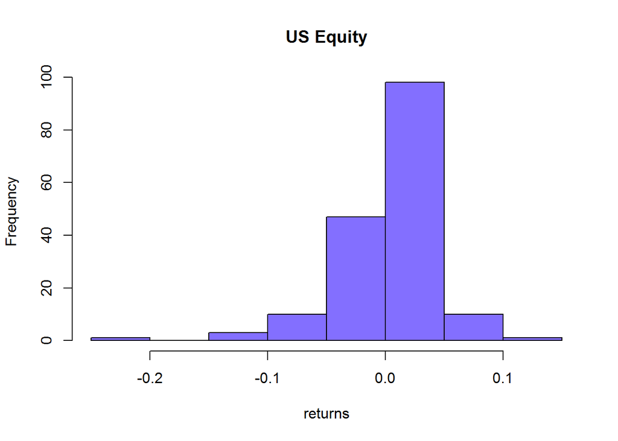

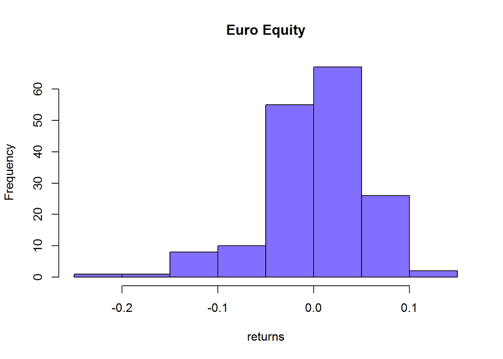

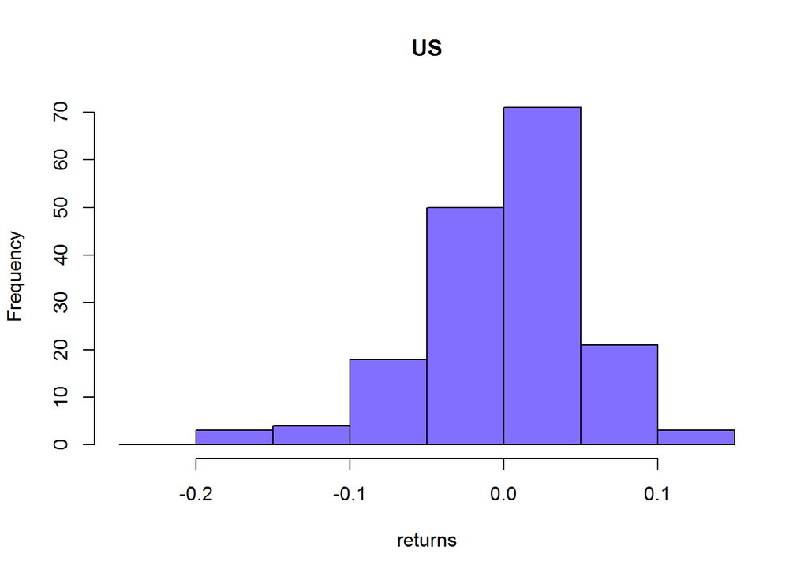

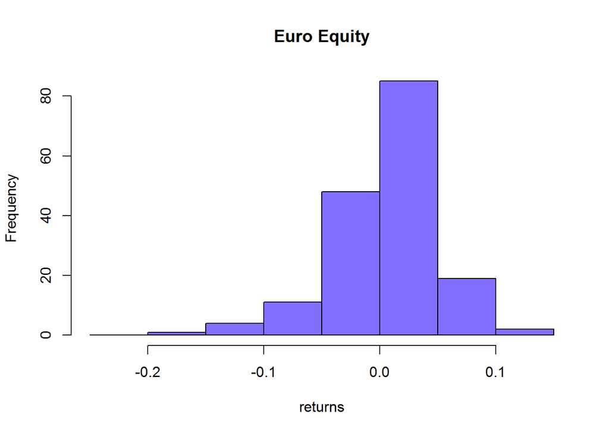

### Descriptive Statistics for Each Market

US Equity

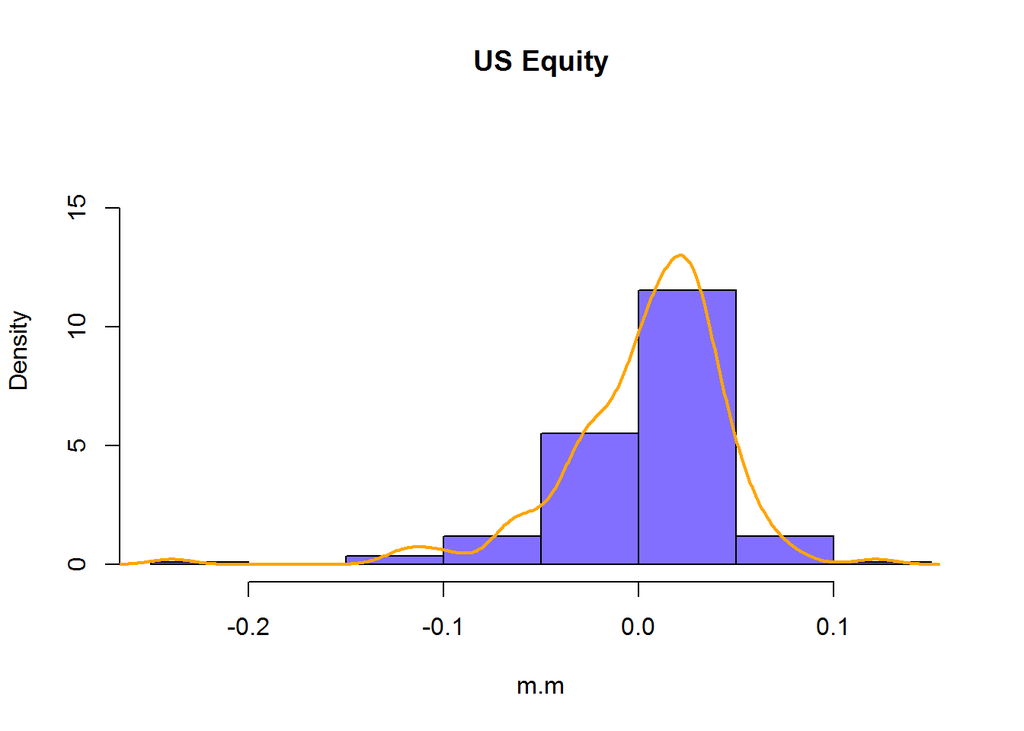

```r
hist(m.m,main="US Equity", col="slateblue1",
     probability=T, ylim=c(0,18))
market.density = density(m.m[-1])
points(market.density,type="l", col="orange", lwd=2)
```

```r
median(m.m)
```

```
## [1] 0.01196
```

```r
quantile(m.m,probs=0.75) - quantile(m.m,probs=0.25)
```

```
##     75%
## 0.04457
```

```r
mean(m.m)
```

```
## [1] 0.003923
```

```r
var(m.m)
```

```
##          mc.z
## mc.z 0.001768
```

```r
sd(m.m)
```

```
## [1] 0.04205
```

```r
skewness(m.m)
```

```
## [1] -1.64
## attr(,"method")
## [1] "moment"
```

```r
kurtosis(m.m)
```

```
## [1] 6.445
## attr(,"method")
## [1] "excess"
```

```r
min(m.m)
```

```
## [1] -0.2394
```

```r
max(m.m)
```

```
## [1] 0.1215
```

Euro Equity

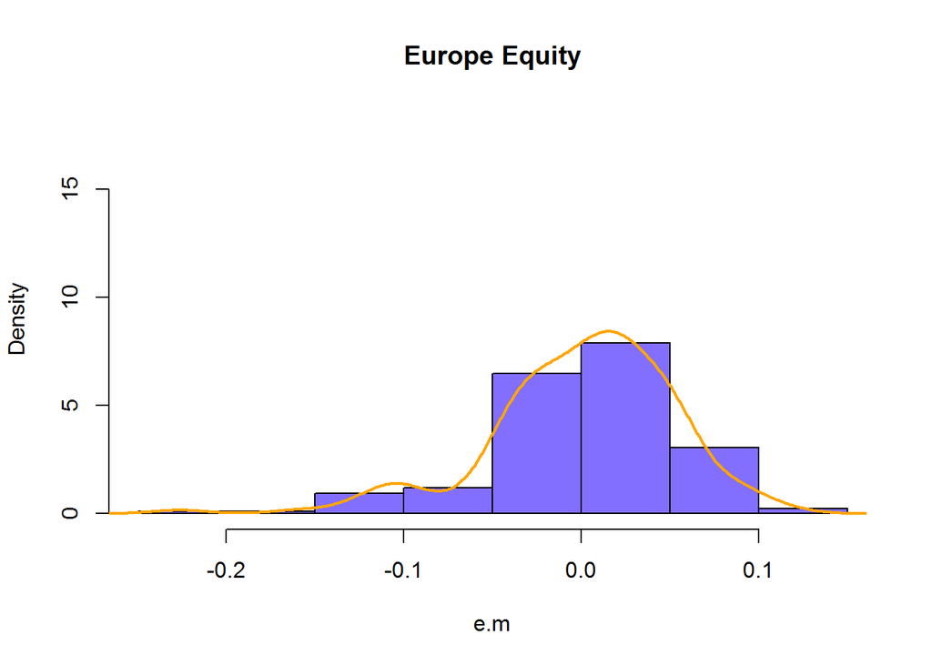

```r
hist(e.m,main="Europe Equity", col="slateblue1",
     probability=T, ylim=c(0,18))
market.density = density(e.m[-1])
points(market.density,type="l", col="orange", lwd=2)
```

```r
median(e.m)
```

```
## [1] 0.007262
```

```r
quantile(e.m,probs=0.75) - quantile(e.m,probs=0.25)
```

```
##     75%
## 0.06186
```

```r
mean(e.m)
```

```
## [1] 0.001048
```

```r
var(e.m)
```

```
##          ec.z
## ec.z 0.002699
```

```r
sd(e.m)
```

```
## [1] 0.05195
```

```r
skewness(e.m)
```

```
## [1] -0.9227
## attr(,"method")
## [1] "moment"
```

```r
kurtosis(e.m)
```

```
## [1] 1.906
## attr(,"method")
## [1] "excess"
```

```r
min(e.m)
```

```
## [1] -0.2261
```

```r
max(e.m)
```

```
## [1] 0.1157
```

## **Box Plots and Scatter Plots**

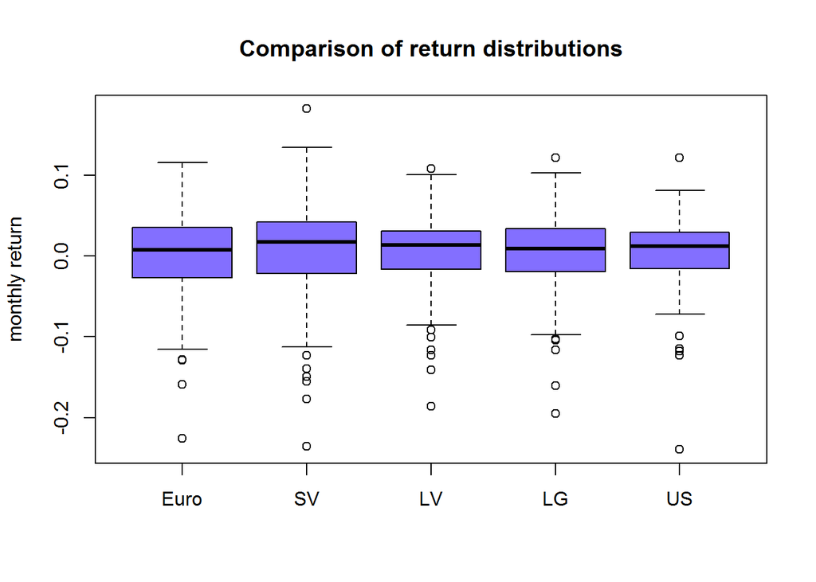

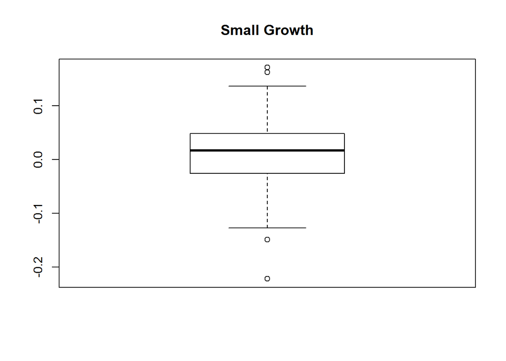

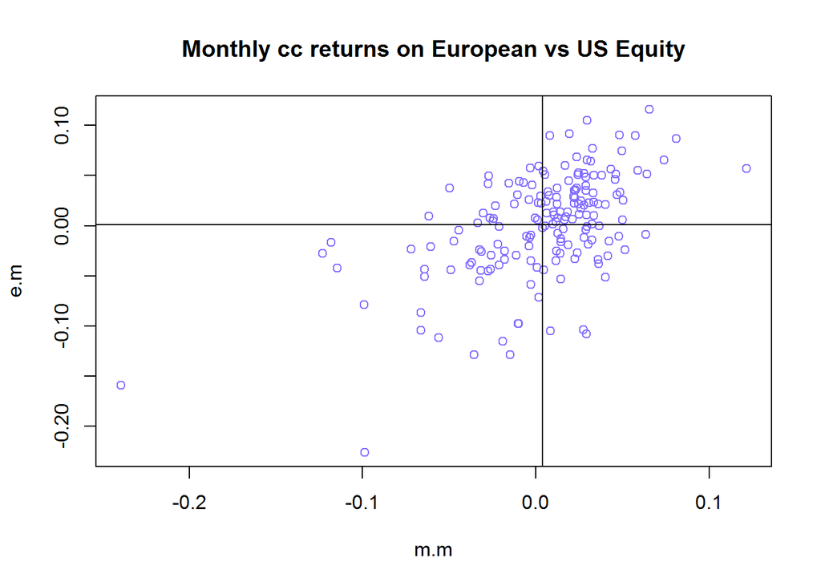

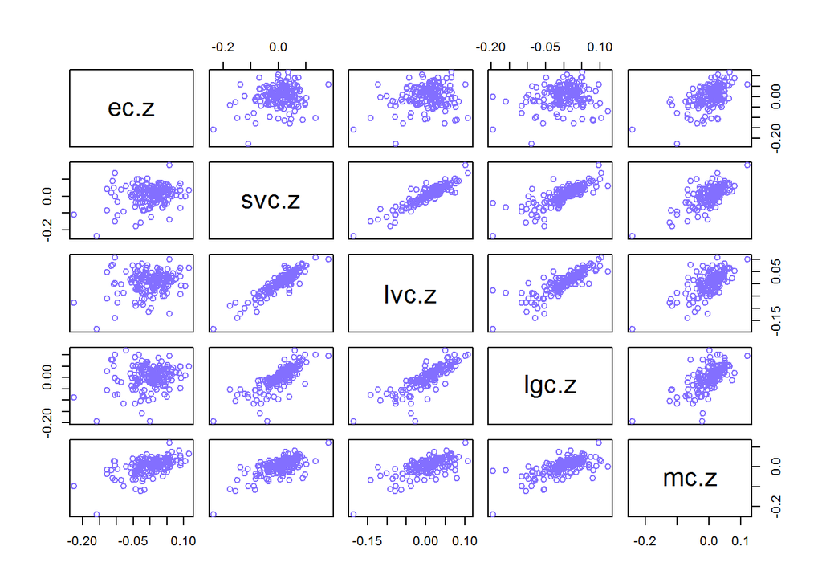

## *Comparing the Market Return with that of an IDD Gaussian Distribution with the same Mean and SD as US Equity*

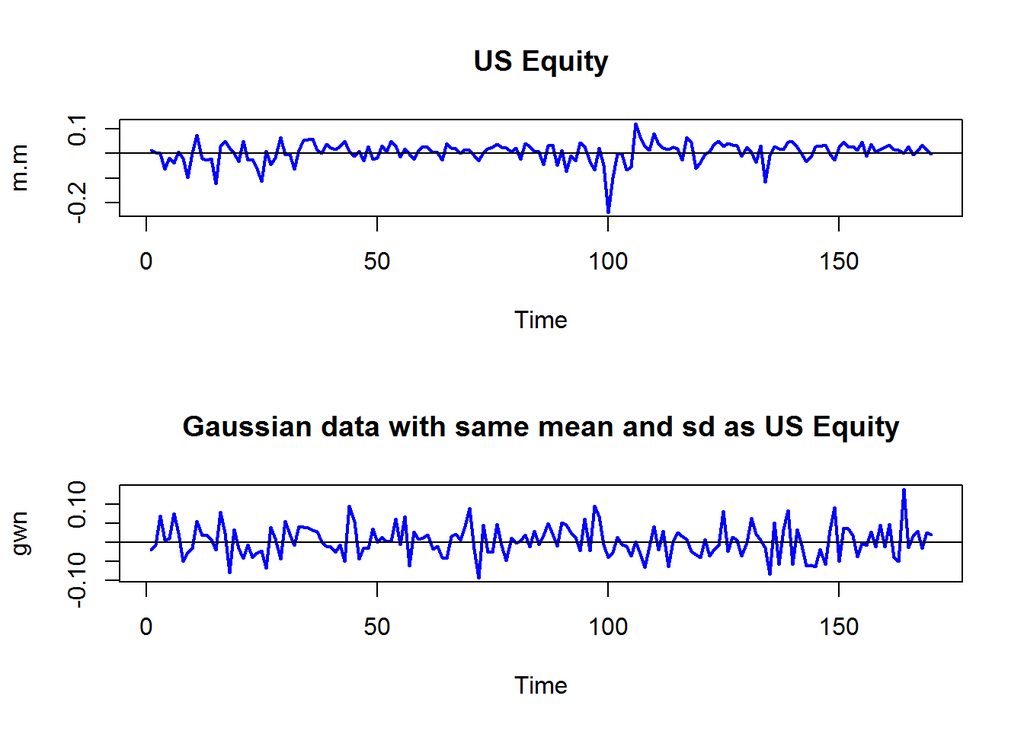

*US data seems more clustered around the mean with large infrequent outliers*

### *Comparing the Cumulative Distribution of the standardized US data with a normal distribution*

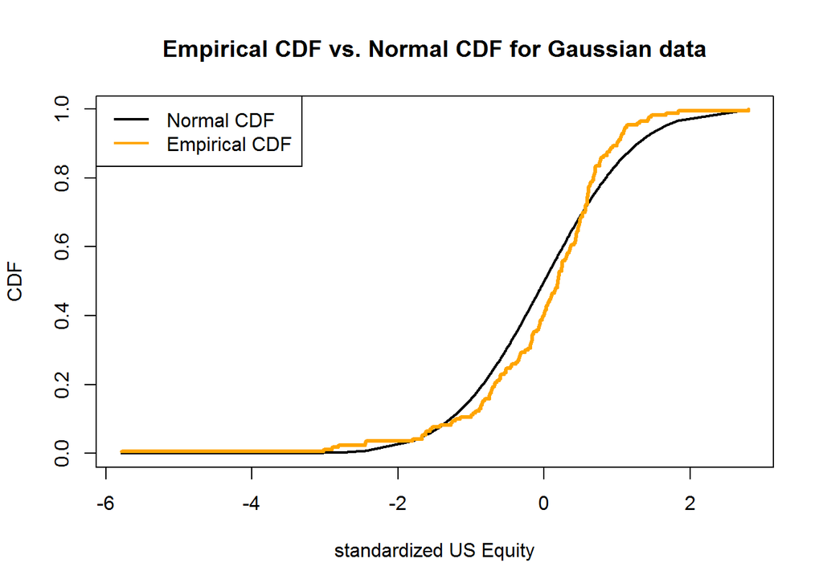

*the CDF comparison suggests thicker tails for the market*

```
##       1%       5%
## -0.11958 -0.06528
```

```
## [1] -0.09389 -0.06524
```

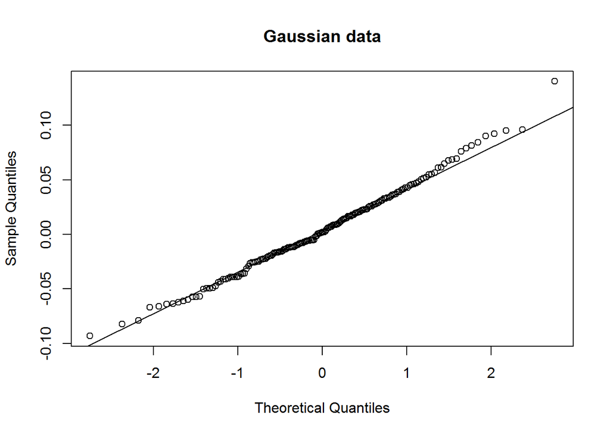

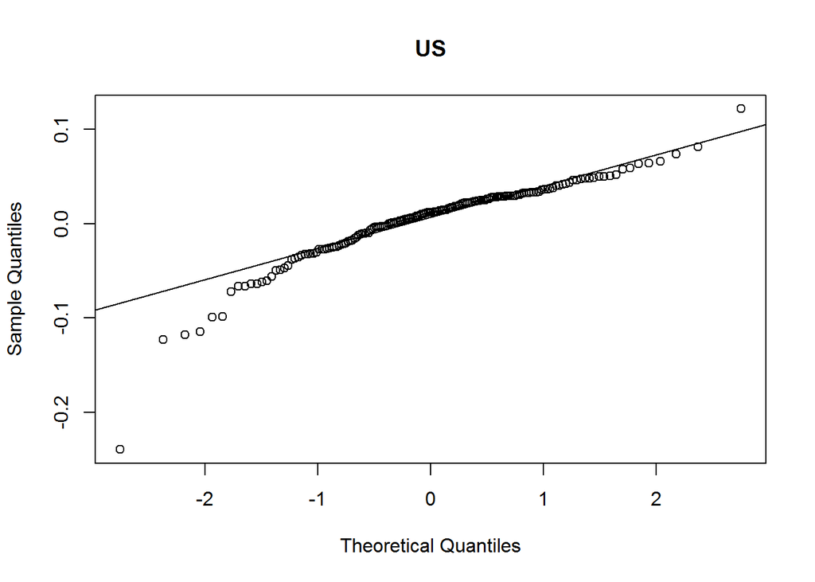

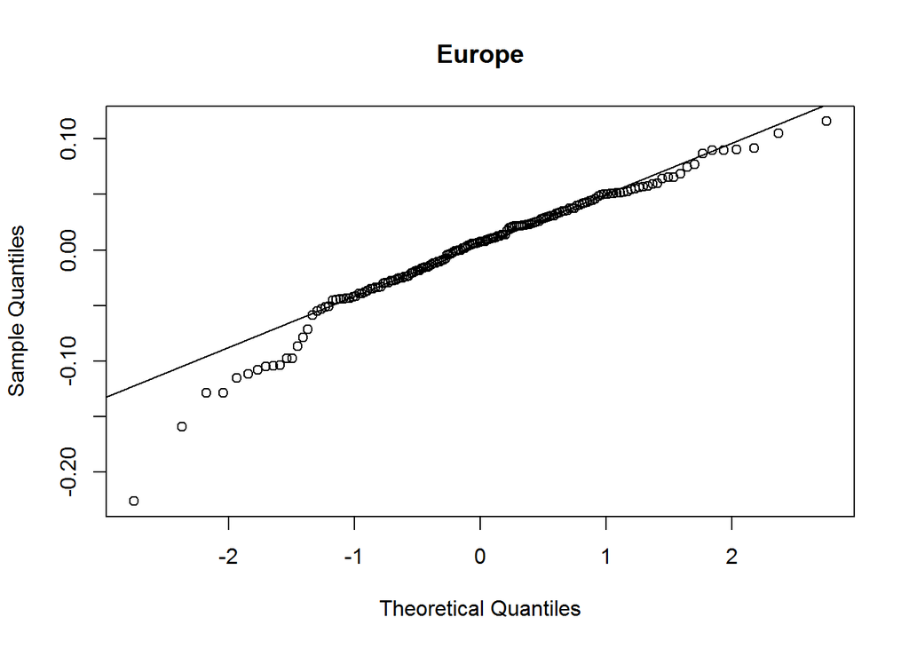

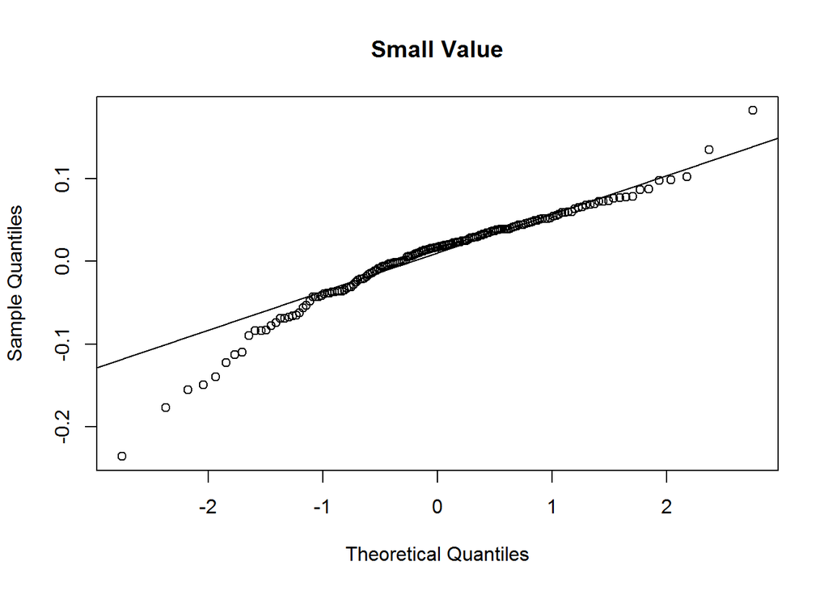

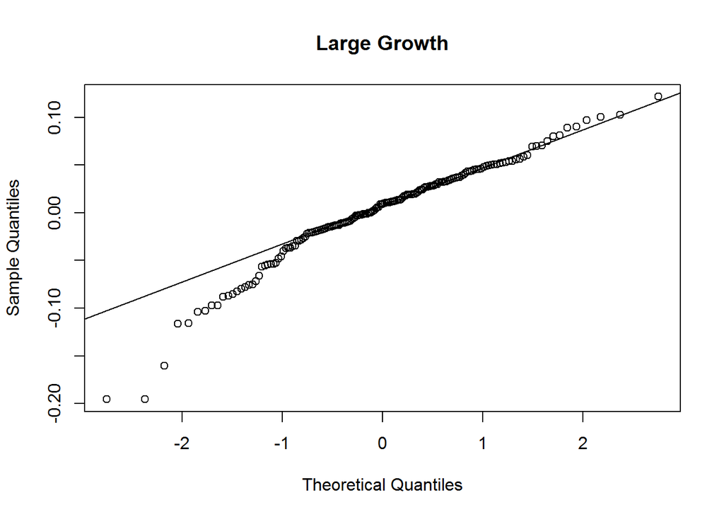

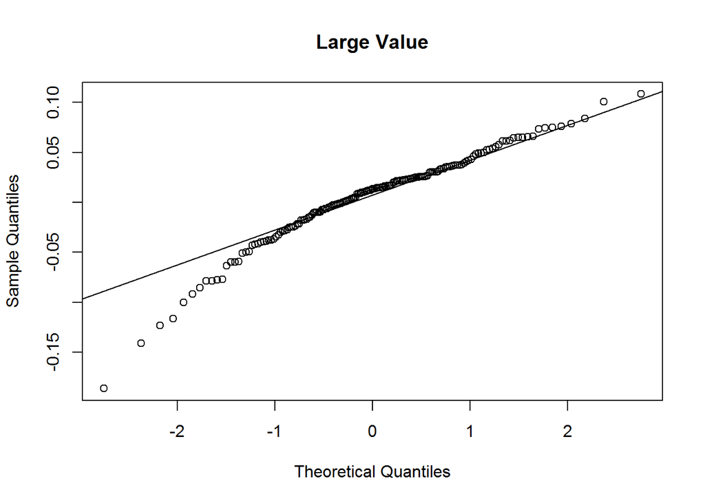

## Constant Expected Return (CER) Model Calibrated to monthly market return

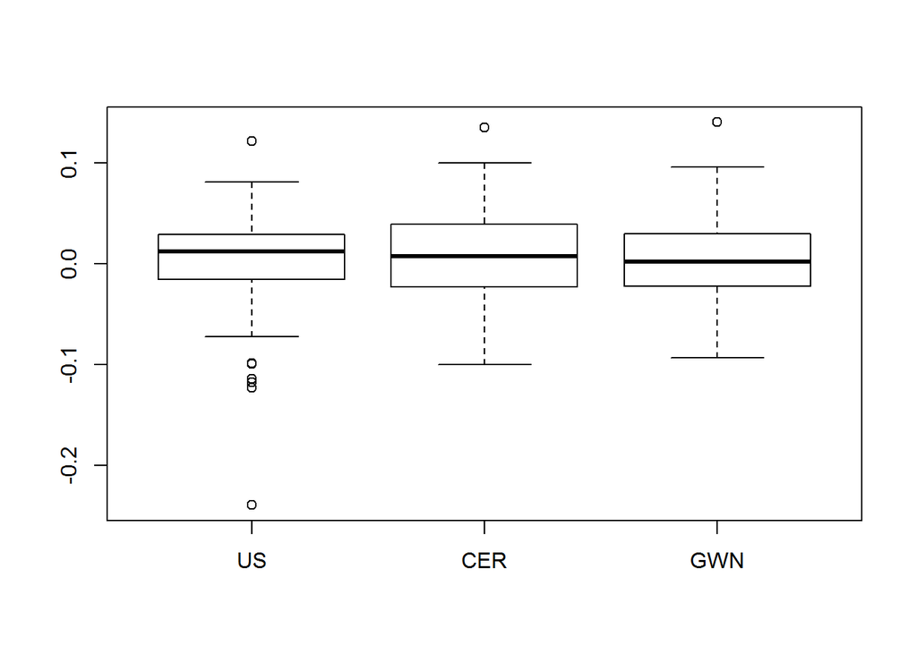

```r
mu = mean(m.m)
sd.e = sd(m.m)
nobs = 170
set.seed(114)
sim.e = rnorm(nobs, mean=0, sd=sd.e)
sim.ret = mu + sim.e
boxplot(cbind(m.m,sim.ret,gwn), names=c("US","CER","GWN"))
```

### **Comparing Market Return with the Random Walk Model, controlling for SD of errors and Mean of return**

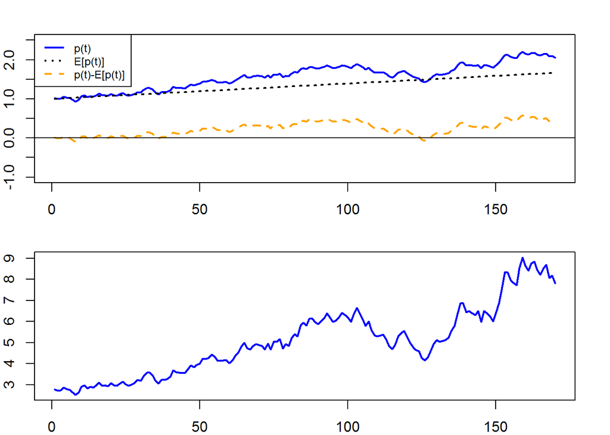

```r
mu = mean(m.m)
sd.e = sd(m.m)
nobs = 170
set.seed(132)
sim.e = rnorm(nobs, mean=0, sd=sd.e)
sim.p = 1 + mu*seq(nobs) + cumsum(sim.e)
sim.P = exp(sim.p)
par(mfrow=c(2,1),mar=rep(2,4))
ts.plot(sim.p, col="blue",lwd=2,
        ylim=c(-1, 2.5), ylab="log price")
lines( (1+mu*seq(nobs)), lty="dotted", col="black", lwd=2)
lines(cumsum(sim.e), col="orange", lty="dashed", lwd=2)
abline(h=0)
legend(x="topleft",legend=c("p(t)","E[p(t)]","p(t)-E[p(t)]"),
       lty=c("solid","dotted","dashed"), col=c("blue","black","orange"),
       lwd=2, cex=c(0.75,0.75,0.75))
ts.plot(sim.P, lwd=2, col="blue", ylab="price")
```

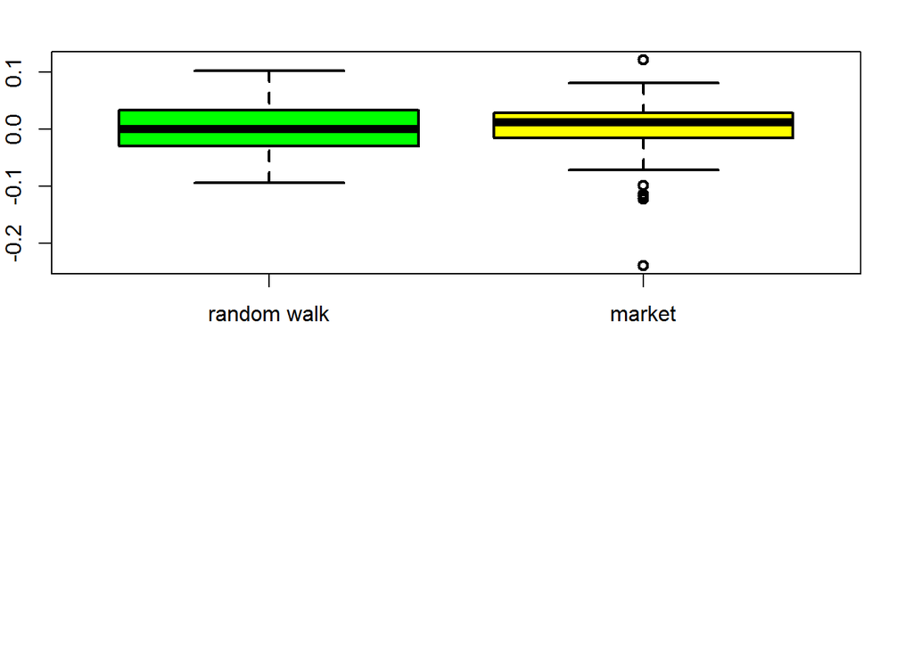

```r
boxplot(cbind(sim.e,m.m), lwd=2, col=c("green","yellow"), names=c("random walk","market"),ylab="price")
```

### Computing means, variances and covariances

*Mean*

```
##     ec.z    svc.z    lvc.z    lgc.z     mc.z
## 0.001048 0.006850 0.005546 0.001375 0.003923
```

*Variance*

```
##     ec.z    svc.z    lvc.z    lgc.z     mc.z
## 0.002699 0.003253 0.002001 0.002699 0.001768
```

*Standard Deviation*

```
##    ec.z   svc.z   lvc.z   lgc.z    mc.z
## 0.05195 0.05704 0.04474 0.05195 0.04205
```

*Covariance Matrix*

```
##            ec.z     svc.z     lvc.z     lgc.z     mc.z
## ec.z  0.0026986 0.0006631 0.0004645 0.0004704 0.001199
## svc.z 0.0006631 0.0032531 0.0023290 0.0023509 0.001652
## lvc.z 0.0004645 0.0023290 0.0020015 0.0019258 0.001274
## lgc.z 0.0004704 0.0023509 0.0019258 0.0026992 0.001442
## mc.z  0.0011989 0.0016523 0.0012743 0.0014422 0.001768
```

*Correlation Matrix*

```
##         ec.z  svc.z  lvc.z  lgc.z   mc.z
## ec.z  1.0000 0.2238 0.1999 0.1743 0.5489
## svc.z 0.2238 1.0000 0.9128 0.7934 0.6890
## lvc.z 0.1999 0.9128 1.0000 0.8286 0.6775
## lgc.z 0.1743 0.7934 0.8286 1.0000 0.6602
## mc.z  0.5489 0.6890 0.6775 0.6602 1.0000
```

### Estimated standard error for mean and Confidence Intervals for the mean

```
##       muhat.vals se.muhat tratios
## ec.z    0.001048 0.003984  0.2632
## svc.z   0.006850 0.004374  1.5660
## lvc.z   0.005546 0.003431  1.6164
## lgc.z   0.001375 0.003985  0.3451
## mc.z    0.003923 0.003225  1.2165
```

*in some cases the se of the mean is even bigger than the mean itself! (in large growth)*

### compute exact 95% confidence intervals

```r
t.975 = qt(0.975, df=99)
mu.lower = muhat.vals - t.975*se.muhat
mu.upper = muhat.vals + t.975*se.muhat
mu.width = mu.upper - mu.lower
cbind(mu.lower,mu.upper,mu.width)
```

```
##        mu.lower mu.upper mu.width
## ec.z  -0.006857 0.008954  0.01581
## svc.z -0.001829 0.015530  0.01736
## lvc.z -0.001262 0.012354  0.01362
## lgc.z -0.006531 0.009282  0.01581
## mc.z  -0.002476 0.010322  0.01280
```

*The Standard Error for the mean values are very big when compared to the mean values, indicating very low estimation precision*

### compute estimated standard error for Variance and Standard Deviation

```r
se.sigma2hat = sigma2hat.vals/sqrt(nobs/2)
se.sigmahat = sigmahat.vals/sqrt(2*nobs)
cbind(sigma2hat.vals,se.sigma2hat)
```

```
##       sigma2hat.vals se.sigma2hat
## ec.z        0.002699    0.0002927
## svc.z       0.003253    0.0003528
## lvc.z       0.002001    0.0002171
## lgc.z       0.002699    0.0002928
## mc.z        0.001768    0.0001918
```

```r
cbind(sigmahat.vals,se.sigmahat)
```

```
##       sigmahat.vals se.sigmahat
## ec.z        0.05195    0.002817
## svc.z       0.05704    0.003093
## lvc.z       0.04474    0.002426
## lgc.z       0.05195    0.002818
## mc.z        0.04205    0.002280
```

```r
# compute approx 95% confidence intervals
sigma2.lower = sigma2hat.vals - 2*se.sigma2hat
sigma2.upper = sigma2hat.vals + 2*se.sigma2hat
sigma2.width = sigma2.upper - sigma2.lower
cbind(sigma2.lower,sigma2.upper,sigma2.width)
```

```
##       sigma2.lower sigma2.upper sigma2.width
## ec.z      0.002113     0.003284    0.0011708
## svc.z     0.002547     0.003959    0.0014114
## lvc.z     0.001567     0.002436    0.0008684
## lgc.z     0.002114     0.003285    0.0011711
## mc.z      0.001384     0.002151    0.0007670
```

```r
sigma.lower = sigmahat.vals - 2*se.sigmahat
sigma.upper = sigmahat.vals + 2*se.sigmahat
sigma.width = sigma.upper - sigma.lower
cbind(sigma.lower,sigma.upper,sigma.width)
```

```
##       sigma.lower sigma.upper sigma.width
## ec.z      0.04631     0.05758    0.011269
## svc.z     0.05085     0.06322    0.012373
## lvc.z     0.03989     0.04959    0.009705
## lgc.z     0.04632     0.05759    0.011270
## mc.z      0.03749     0.04661    0.009121
```

### compute estimated standard error for Correlation

```r
se.rhohat = (1-rhohat.vals^2)/sqrt(nobs)
cbind(rhohat.vals,se.rhohat)
```

```
##      rhohat.vals se.rhohat
## sve       0.2238   0.07286
## lve       0.1999   0.07363
## lge       0.1743   0.07437
## me        0.5489   0.05359
## lvsv      0.9128   0.01280
## lgsv      0.7934   0.02842
## msv       0.6890   0.04029
## lvlg      0.8286   0.02404
## lvm       0.6775   0.04150
## lgm       0.6602   0.04327
```

```r
# compute approx 95% confidence intervals
rho.lower = rhohat.vals - 2*se.rhohat
rho.upper = rhohat.vals + 2*se.rhohat
rho.width = rho.upper - rho.lower
cbind(rho.lower,rho.upper,rho.width)
```

```
##      rho.lower rho.upper rho.width
## sve    0.07809    0.3695   0.29142
## lve    0.05262    0.3471   0.29453
## lge    0.02557    0.3230   0.29747
## me     0.44173    0.6561   0.21435
## lvsv   0.88715    0.9384   0.05120
## lgsv   0.73651    0.8502   0.11369
## msv    0.60844    0.7696   0.16114
## lvlg   0.78048    0.8766   0.09617
## lvm    0.59446    0.7604   0.16599
## lgm    0.57367    0.7467   0.17307
```

*SE for Variance, Standard Deviation and correlation are much lower, indicating higher precision*

## show risk return tradeoffs

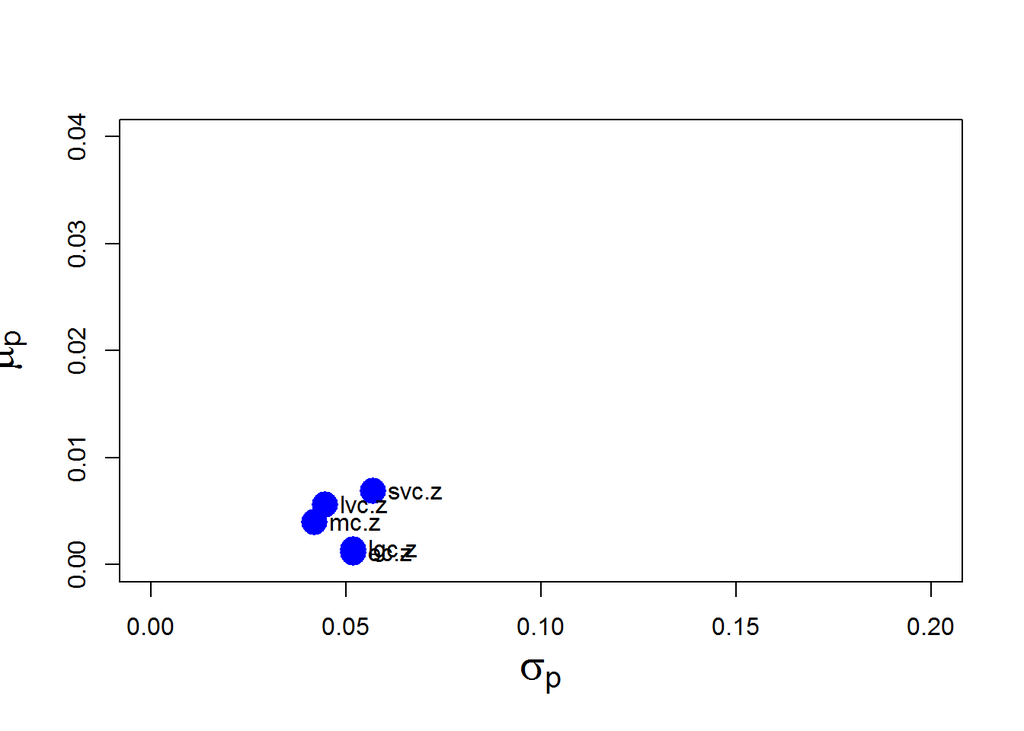

```r
cex.val = 1
plot(sigmahat.vals, muhat.vals,  ylim=c(0, 0.04), xlim=c(0, 0.20), ylab=expression(mu[p]),
     xlab=expression(sigma[p]), pch=16, col="blue", cex=2.5, cex.lab=1.75)
text(sigmahat.vals, muhat.vals, labels=names(muhat.vals), pos=4, cex = cex.val)
```

### Portfolio Construction and Optimization

### compute equally weighted portfolio of four asset classes

```
## Call:
## getPortfolio(er = er, cov.mat = ecov, weights = ew)
##
## Portfolio expected return:     0.009189
## Portfolio standard deviation:  0.03622
## Portfolio weights:
##  ec.z svc.z lvc.z lgc.z
##  0.25  0.25  0.25  0.25
```

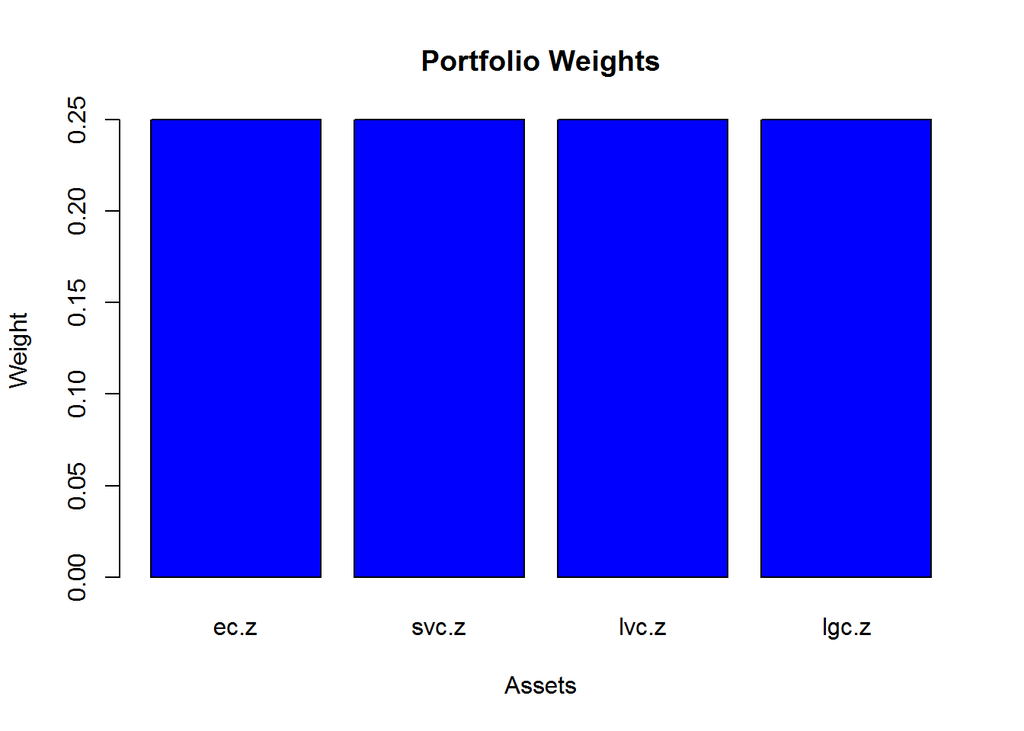

### compute global minimum variance portfolio with shorts allowed

```
## Call:
## globalMin.portfolio(er = er, cov.mat = ecov)
##
## Portfolio expected return:     0.007515
## Portfolio standard deviation:  0.03061
## Portfolio Sharpe Ratio:        0.2095
## Portfolio weights:
##    ec.z   svc.z   lvc.z   lgc.z
##  0.3483 -0.6508  1.0566  0.2459
```

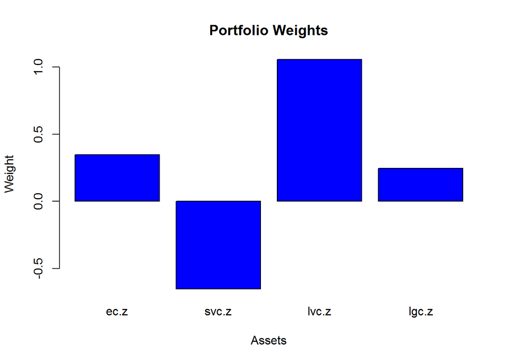

### compute global minimum variance portfolio with shorts not allowed

```
## Call:
## globalMin.portfolio(er = er, cov.mat = ecov, shorts = FALSE)
##
## Portfolio expected return:     0.008166
## Portfolio standard deviation:  0.03291
## Portfolio Sharpe Ratio:        0.2147
## Portfolio weights:
##   ec.z  svc.z  lvc.z  lgc.z
## 0.3875 0.0000 0.4575 0.1550
```

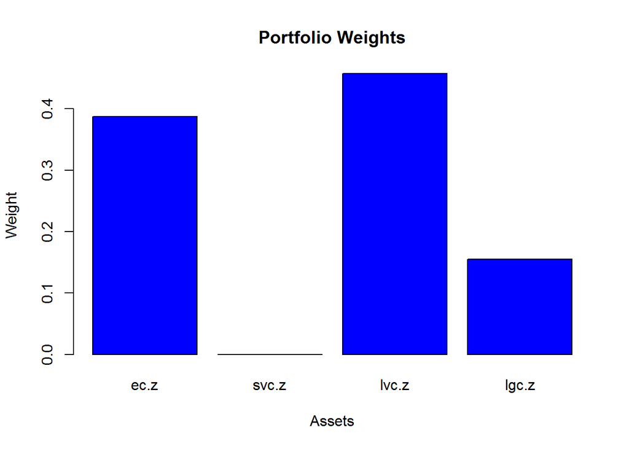

```
## Call:
## efficient.portfolio(er = er, cov.mat = ecov, target.return = target.return)
##
## Portfolio expected return:     0.01191
## Portfolio standard deviation:  0.04727
## Portfolio Sharpe Ratio:        0.2287
## Portfolio weights:
##    ec.z   svc.z   lvc.z   lgc.z
## -0.0365  0.2044  1.4469 -0.6148
```

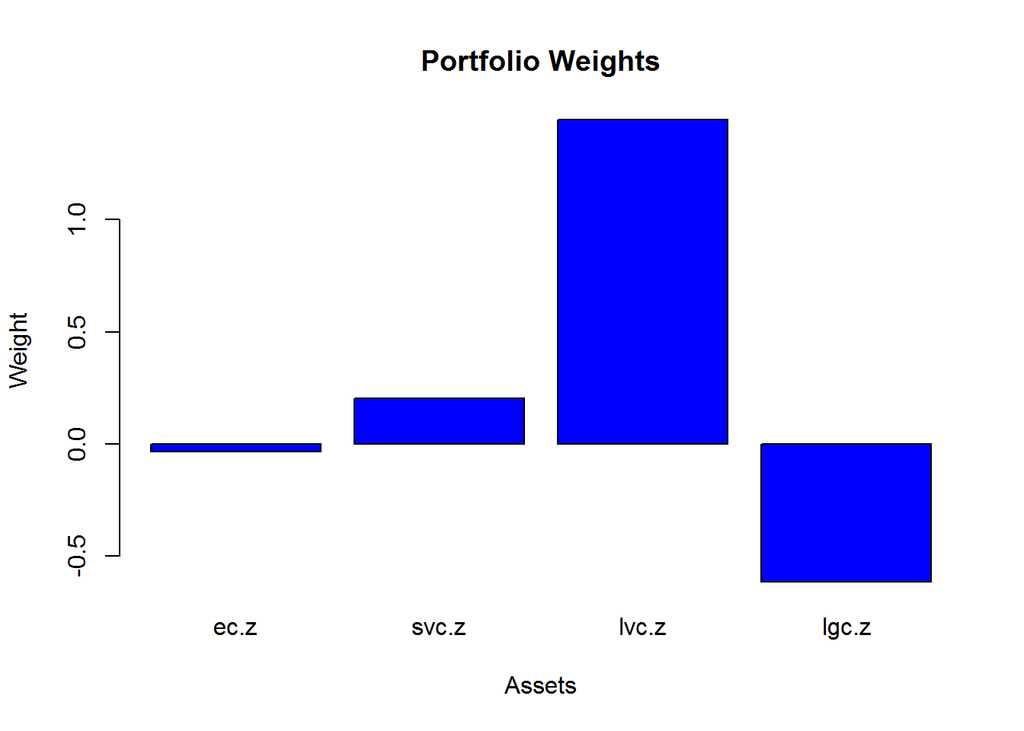

### compute efficient portfolio subject to target return with no short sales

```
## Call:
## efficient.portfolio(er = er, cov.mat = ecov, target.return = target.return,
##     shorts = FALSE)
##
## Portfolio expected return:     0.01191
## Portfolio standard deviation:  0.05167
## Portfolio Sharpe Ratio:        0.2092
## Portfolio weights:
##  ec.z svc.z lvc.z lgc.z
##     0     1     0     0
```

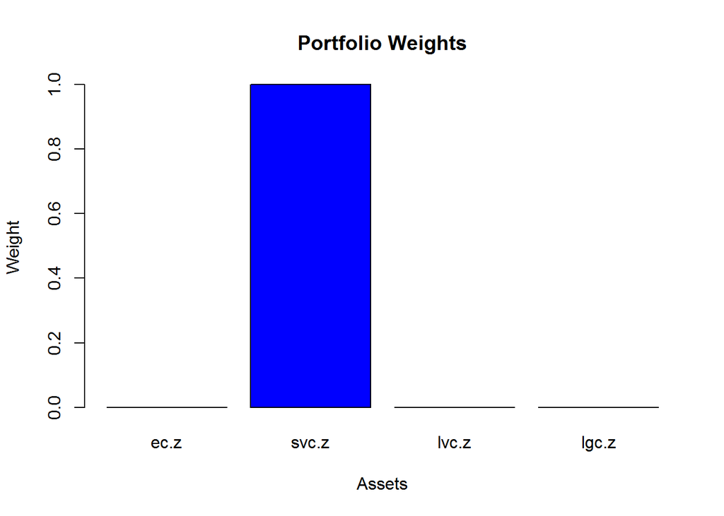